# STAT 134: Concepts of Probability (Summary)

Li Yuan

6/23/2022

# Chapter 0: Prerequisites

## 1. Theory and Identity of Sets

**Definition:** A set is an unordered collection of elements. It looks like $S=$ {$X\in A:$ “property”}.

### i. Theory

**Theory 1:** $A$ is a set, $X\in A$ means $X$ is in the set of $A$.

**Theory 2:** $A, B$ are sets, $A \subseteq B$ means $A$ is a subset of $B$ and for all $X\in A$, $X\in B$.

**Theory 3:** Union $A\cup B=$ {$X\in \Omega:X\in A~or~X\in B$}. If $A_1,A_2,...,A_n$ are sets, then $\cup_{i=1}^nA_i=A_1\cup A_2~\cup~...~\cup~A_n$.

**Theory 4:** Intersection $A\cap B=$ {$X\in \Omega:X\in A~and~X\in B$}. If $A_1,A_2,...,A_n$ are sets, then $\cap_{i=1}^nA_i=A_1\cap A_2~\cap~...~\cap~A_n$.

**Theory 5:** Difference $A\setminus B=$ {$X\in \Omega:X\in A~and~X\notin B$}.

**Theory 6:** Complement $A^c=$ {$X\in \Omega:X\notin A$}.

**Theory 7:** $A$ and $B$ do not intersect, i.e., $A\cap B=\varnothing$.

*Random Event*: Events $A$ and $B$ are incompatible.

**Theory 8:** $A\cap B~\cap~...\cap~N=\varnothing$.

*Random Event*: Events $A, B,...,N$ are incompatible.

**Theory 9:** $A\cap B~\cap~...\cap~N=X$.

*Random Event*: Event $X$ is defined as the simultaneous occurrence of events $A, B,...,N$.

**Theory 10:** $A=0$.

*Random Event*: Event $A$ is impossible.

**Theory 11:** $A=\Omega$.

*Random Event*: Event $A$ must occur.

**Theory 12:** The system $E$ of the sets $A_1, A_2, ..., A_n$ forms a *decomposition* of set $\Omega$ if $A_1\cap A_2~\cap~...\cap~A_n=\Omega$. (This assumes that the sets $A_i$ do not intersect in pairs.)

*Random Event*: *Experiment* $E$ consists of determining which of the events $A_1,A_2,...A_n$ occurs. We therefore call $A_1,A_2,...,A_n$ the possible results of experiment $E$.

### ii. Identity

**Identity 1:** $A\cap \Omega=A$, $A\cup\varnothing=A$ (Identity laws).

**Identity 2:** $A\cup\Omega=\Omega$, $A\cap\varnothing=\varnothing$ (Domination laws).

**Identity 3:** $A\cup A=A$, $A\cap A=A$ (Idempotent laws).

**Identity 4:** $(A^c)^c=A$ (Complementation law).

**Identity 5:** $A\cup B=B\cup A$, $A\cap B=B\cap A$ (Commutative laws).

**Identity 6:** $A\cup(B\cup C) = (A\cup B)\cup C$, $A\cap(B\cap C) = (A\cap B)\cap C$ (Associative laws).

**Identity 7:** $A\cup(B\cap C) = (A\cup B)\cap(A\cup C)$, $A\cap(B\cup C) = (A\cap B)\cup(A\cap C)$ (Distributive laws).

**Identity 8:** $(A\cap B)^c=A^c\cup B^c$, $(A\cup B)^c=A^c\cap B^c$ (De Morgan’s laws).

**Identity 9:** $A\cup(A\cap B)=A$, $A\cap(A\cup B)=A$ (Absorption laws).

**Identity 10:** $A\cup A^c=\Omega$, $A\cap A^c=\varnothing$ (Complement laws).

## 2. Counting Methods

### i. One-to-one Correspondence

If $A$ is a set consisting of finite elements there is a one-to-one correspondence between the elements in $A$ and elements in $B$. Then we know that $B$ is finite and $A$ and $B$ have the same number of elements.

### ii. Addition Principle

If a first task can be done in $n_1$ ways and a second task in $n_2$ ways, and if these tasks cannot be done at the same time, then there are $n_1+n_2$ ways to do either tasks.

### iii. Multiplication Principle

If experiment $A$ has $m$ outcomes and $B$ has $n$ outcomes, then the sequence of experiments $(A, B)$ has $m\times n$ outcomes.

### iv. Permutations

A permutation is an ordered arrangement of objects. It is well-known as the number of orderings for elements is

$$n!=1\times2\times...\times(n-2)\times(n-1)\times n.$$

In general, if we have a set $S=$ {$A_1,A_2,...,A_n$}, and we need to choose $r$ elements and put them in order, then there are

$$P(n,r)=\frac{n!}{(n-r)!}=n\times (n-1)\times ... \times (n-r+1)$$

orderings for sampling *without replacement*.

Moreover, the number of orderings for sampling *with replacement* is

$$P^R(n,r)=n^r.$$

### v. Combinations

A combination is an unordered arrangement of objects. It is well-known as the *binomial coefficient*.

In general, if we have a set $S=$ {$A_1,A_2,...,A_n$}, and we need to choose $r$ elements, no matter what the order is, then there are

$$C(n,r)=\binom{n}{r}=\frac{P(n,r)}{P(r,r)}=\frac{n!}{r!(n-r)!}$$
combinations *without replacement*.

Moreover, the number of combinations *with replacement* is

$$C^R(n,r)=\frac{(n+r-1)!}{r!(n-r)!}.$$

*Note: When sampling without replacement, combinations is always less than or equal to permutations. If $r=1$, then combinations and permutations are equal.*

# Chapter 1: Introduction to Probability

## 1. Axioms

Let $\Omega$ be a collection of elements $a, b, c,...$, which we shall call *elementary events*, and $E$ a set of subsets of $\Omega$; the elements of the set $E$ will be called *random events*.

- *$E$ is a field of sets.*
- *$E$ contains the set $\Omega$.*
- *To each set $A$ in $E$ is assigned a non-negative real number $P(A)$. This number $P(A)$ is called the probability of the event A.*
- *$P(\Omega)$ equals to 1.*
- *If $A$ and $B$ have no element in common, then $P(A\cup B)=P(A)+P(B)$.*

A system of sets, $E$, together with a definite assignment of numbers $P(A)$, satisfying all the axioms above, is called *a field of probability*.

Our system of the axioms above is *consistent*, but it is not *complete* in various problems in the theory of probability different fields of probability have to be examined.

## 2. Equally Likely Outcomes

If all outcomes in a finite set $\Omega$ are equally likely, the probability of $A$ is the number of outcomes in $A$ divided by the total number of outcomes:

$$P(A)=\frac{number~of~A}{number~of~\Omega}$$

Probabilities defined by this formula for equally likely outcomes are fractions between 0 and 1. The number 1 represents certainty: $P(\Omega)=1$. The number 0 represents impossibility: $P(A)=0$ if there is no way that $A$ could happen. Then $A$ corresponds to the empty set, or set with no elements, denoted $\varnothing$. So $P(\varnothing)=0$. Intermediate probabilities may be understood as various degrees of certainty.

## 3. The Fair Odds Rule

In a fair bet, the payoff odds equal to chance odds. For example, we flip a fair coin, and let $A$ be the event that we get *heads*. Then $P(A)=1-P(A)$.

## 4. Interpretations

### i. Frequentist Interpretation

Long run proportion of occurrences converges to a number, and this number is probability:

*Example:* Flip a coin many times, the relative frequency of heads will be closed to 0.5 as the number of tosses increases.

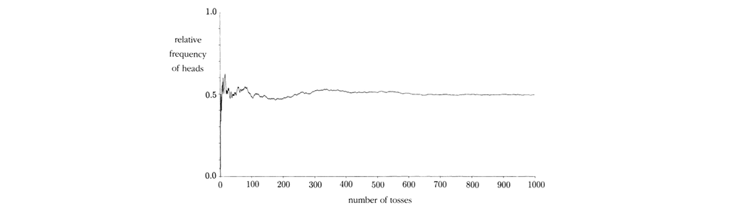

### ii. Baysian (Subjectivist) Interpretation

Probability is a degree of certainty of an outcome.

*Example 1:* It is unlikely that there will be an earthquake in Novosibirsk next year.

*Example 2:* The chance of snow tomorrow in Moskva is 30%.

### iii. Probability and Statistics are Inverse

Statistics is that given the sample we have, we want to predict the population. However, probability is that given the population, we have to predict the sample.

### iv. Mathematical Formulist

Probability is a function that takes in collections of outcomes and give a number. This refers to the five axioms in 1.1.

## 5. Basic Rules of Probability

### i. Basics

1. If $A$ is an event, then $0\leq P(A)\leq1$.
2. The sum of the probabilities of all possible outcomes , $\Omega$, is 1, $P(\Omega)=1$.
3. $P(A\cap B)=P(A ~and~ B)=P(both~event~A~occurs~and~event~B~occurs)$.
4. $P(A\cup B)=P(A ~or~ B)=P(event~A~occurs~or~event~B~occurs~or~both~occur)$.
5. $P(A\cap B)=0$ if events $A$ and $B$ are disjoint.
6. $P(A\cup A^c)=P(\Omega)=1$.
7. $P(A\cap A^c)=P(\varnothing)=0$.

### i. Partitioning

Suppose there are two events $A$ and $B$ in $\Omega$, then we have

$$P(A)=P(A\cap B)+P(A\cap B^c).$$

### ii. Complement Rule

$$P(A)=1-P(A^c)$$

*Proof:* We know that $P(A\cup A^c)=P(A)+P(A^c)-P(A\cup A^c)=1=P(\Omega)$ from the inclusion-exclusion rule. We also know that $P(A\cup A^c)=P(\varnothing)=0$ from (7) in 1.5.i. As a result, $P(A\cup A^c)=P(A)+P(A^c)=1\Rightarrow P(A)=1-P(A^c).~\square$

### iii. Sum Rule

$$P(A\cup B)=P(A)+P(B)$$

If $A$ and $B$ are disjoint events.

*Proof:* By the inclusion-exclusion rule, we know that $P(A\cup B)=P(A)+P(B)-P(A\cap B)$. Since $A$ and $B$ are disjoint events, we can conclude that $P(A\cap B)=P(\varnothing)=0$ from (5) in 1.5.i. As a result, $P(A\cup B)=P(A)+P(B)-0=P(A)+P(B).~\square$

### iv. Inclusion-exclusion Rule

$$P(A\cup B)=P(A)+P(B)-P(A\cap B).$$

*Proof:* By partitioning, we can consider $P(A\cup B)$ as two parts, which are $P(A)$ and $P(A^c\cap B)$ so $P(A\cup B)=P(A)+P(A^c\cap B)$. Still by partitioning, $P(B)=P(A^c\cap B)+P(A\cap B)\Rightarrow P(A^c\cap B)=P(B)-P(A\cap B)$. As a result, $P(A\cup B)=P(A)+P(A^c\cap B)=P(A)+P(B)-P(A\cap B). \square$

General form of the inclusion-exclusion rule is

$$P(\cup_{i=1}^nA_i)=P(\Sigma_{i=1}^nA_i)-P(\Sigma_{i<j\le n}A_i\cap A_j )+P(\Sigma_{i<j<k\le n}A_i\cap A_j\cap A_k)+...+(-1)^{n+1}(A_i\cap A_j~\cap ... \cap ~A_n).$$

*Proof:* We can proof this general form of the inclusion-exclusion rule by using mathematical induction.

Base cases: When $n=1$, $P(\cup_{i=1}^1A_i)=P(A_1)$. When $n=2$, $P(\cup_{i=1}^2A_i)=P(\Sigma_{i=1}^2A_i)-P(\Sigma_{i<j\le 2}A_i\cap A_j)=P(A_1)+P(A_2)-P(A_1\cap A_2)$.

Induction hypothesis: We assume that $P(\cup_{i=1}^nA_i)=P(\Sigma_{i=1}^nA_i)-P(\Sigma_{i<j\le n}A_i\cap A_j )+P(\Sigma_{i<j<k\le n}A_i\cap A_j\cap A_k)+...+(-1)^{n+1}(A_i\cap A_j~\cap ... \cap ~A_k)$ is always true for positive integers $n$.

Inductive step: $P(\cup_{i=1}^{n+1}A_i)=P(\Sigma_{i=1}^{n+1}A_i)-P(\Sigma_{i<j\le n+1}A_i\cap A_j )+P(\Sigma_{i<j<k\le n+1}A_i\cap A_j\cap A_k)+...+(-1)^{n+1}(A_i\cap A_j~\cap ... \cap ~A_{n+1})$

$=[P(\Sigma_{i=1}^{n}A_i)+P(A_{n+1})]-[P(\Sigma_{i<j\le n}A_i\cap A_j)+P(\Sigma_{i<j\le n+1}A_i\cap A_{n+1})]+[P(\Sigma_{i<j<k\le n}A_i\cap A_j\cap A_k)+P(\Sigma_{i<j<k\le n+1}A_i\cap A_j\cap A_{n+1})]+...+(-1)^{n+1}(A_i\cap A_j~\cap ... \cap ~A_{n+1})$

$=P(\cup_{i=1}^nA_i)+P(A_{n+1})-P(\Sigma_{i<j\le n+1}A_i\cap A_{n+1})+P(\Sigma_{i<j<k\le n+1}A_i\cap A_j\cap A_{n+1})+...+(-1)^{n+1}(A_i\cap A_j~\cap ... \cap ~A_{n+1})$

$=P(\cup_{i=1}^nA_i)+P(A_{n+1})-P(\cup_{i=1}^nA_iA_{n+1}).~\square$

## 6. Conditional Probability and Independent Rules

### i. Conditional Probability Rules

1. We usually denote the following probability as *“The probability of $A$ given $B$.”*

$$P(A|B)=\frac{P(A\cap B)}{P(B)}=\frac{P(B\cap A)}{P(B)}$$

2. By the multiplication rule, we have

$$P(A\cap B)=P(B\cap A)=P(B)\cdot P(A|B).$$

3. By partitioning, we have

$$P(A)=P(A\cap B)+P(A\cap B^c)=P(B)\cdot P(A|B)+P(B^c)\cdot P(A|B^c)$$

4. Multiple Events Conditioning Multiplication Rule

Suppose we have $n$ events, which are $A_1, A_2, A_3, ..., A_n$, then we have

$$P(A_1\cap A_2\cap~...~\cap A_n)=P(A_1)\cdot P(A_2|A_1)\cdot P(A_3|A_1\cap A_2)\cdot~...~\cdot P(A_n|A_1\cap A_2\cap~...~\cap A_{n-1}).$$

### ii. Idependent Rules

1. $A$ and $B$ are independent if knowing that one had occurred gave us no information about whether the other had occurred: if $P(B)\neq 0$ and $P(A)\neq 0$, then

$$P(A|B)=P(A)\Leftrightarrow P(B|A)=P(B)\Leftrightarrow P(A\cap B)=P(A)\cdot P(B)$$

Therefore, we usually define $A$ and $B$ are independent if an only if $P(A)\cdot P(B)=P(A\cap B)$. Notice that here $A$ and $B$ can have zero probability.

2. $A_1,A_2,...,A_n$ are *mutually independent* if for any sub-collection $A_{i1}, A_{i2}, ..., A_{ik}$, $P(A_{i1}\cap A_{i2}\cap~...~\cap A_{ik})=P(A_{i1})\cdot P(A_{i2})\cdot~...~\cdot P(A_{ik})$.

$A_1,A_2,...,A_n$ are *pairwise independent* if for all $i\neq j$, $P(A_i\cap A_j)=P(A_i)\cdot P(A_j)$.

If $A_1, A_2, ..., A_n$ are pairwise independent and $P(A_1\cap A_2\cap~...~\cap A_n)=P(A_1)\cdot P(A_2)\cdot~...~\cdot P(A_n)$, then they are independent.

3. If $A_1,A_2,...,A_n$ are independent, then

$$P(A_1\cap A_2\cap~...~\cap A_n)=P(A_1)\cdot P(A_2)\cdot~...~\cdot P(A_n).$$

## 7. Bayes’ Rule

1. $$P(A|B)=\frac{P(A\cap B)}{P(B)}=\frac{P(A)\cdot P(B|A)}{P(A)\cdot P(B|A)+P(A^c)\cdot P(B|A^c)}$$

In general, let $B$ and $A_1, A_2,...,A_n$ be events where the $A_i$ are disjoint, $\cup_{i=1}^nA_i=\Omega$, and $P(A_i)>0$ for all $i$. Then

$$P(A_j|B)=\frac{P(B|A_j)\cdot P(A_j)}{\Sigma_{i=1}^nP(B|A_i)\cdot P(A_i)}.$$

2. Bayes’ rule for odds states that *posterior = prior odds* $\times$ *likelihoods*. If $P(B_i)=cR_i$ for some constant $c$ and $P(A|B_i)=dL_i$ for some constant $d$, then the *posterior odds ratios* $P(B_i|A)$ to $P(B_j|A)$ are simply $R_iL_i$ to $R_jL_j$, and $P(B_i|A)=\frac{R_iL_i}{R_1L_1+R_2L_2+...+R_nL_n}$

## 8. Distributions

Suppose I have a collection of outcomes $\Omega=$ {$x_1,x_2,...,x_n$}. A distribution is a collection of probability assigned to the outcomes.

### i. Distribution is a Histogram

When rolling 2 fair, six-sided dices. The distribution of the sum should looks like Figure 2: Dice Sum Distribution.

### ii. Empirical Distribution

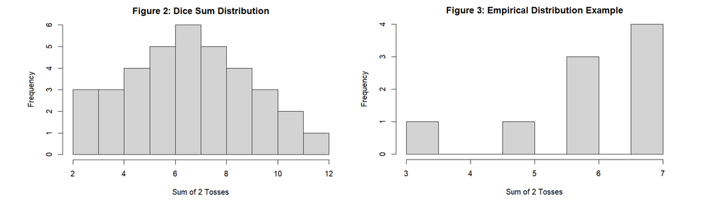